# DeeDee User Guide

Lea Rothörl

4/14/2021

## What DeeDee is for

When you want to compare results from multiple Differential Expression Analyses (DEAs), the DeeDee package is your friend. It contains various functions that help shed light on the similarities and differences between the experiments in question. DeeDee is designed to be used after the application of a DE analysis program (like DESeq2, edgeR or limma) on the single DEAs.

## How to Install

To use DeeDee, the following packages need to be installed in your environment:

- checkmate
- DescTools
- dplyr
- ffpe
- ggplot2
- ggplotify
- ggvenn
- gplots
- idr
- tibble
- UpSetR
- viridis

## Example Dataset Used in this Vignette

The examples in the following chapters utilize the data from the Bioconductor package `macrophage`([Human macrophage immune response](https://bioconductor.org/packages/release/data/experiment/html/macrophage.html)). The macrophage dataset includes data from 24 RNA-seq samples of human macrophages exposed to different conditions: naive, associated with IFNg (an interferon), SL1344 (a strain of Salmonella), or both. The preprocessing of the data was done using DESeq2, obtaining the following four DEAs: naive vs. IFNg, IFNg vs. both, naive vs. Salmonella, and Salmonella vs. both.

## What to Provide

The main DeeDee functions work on tables of logFC- (“logFC”) and p-values (“pval”) from DEAs, with the gene identifiers as row names. This table can be built by the user manually or by using `deedee_prepare`. The `deedee_prepare` function accepts results from three of the most used R DE analysis packages (DESeq2, edgeR, limma) and converts them to digestible tables. Which of these packages was used to analyze the raw data needs to be specified using the parameter `input_type`. If, for example, you have a DESeq2 result called `DESeq2_res` and want to convert it to a DeeDee table, you can use the following code chunk to do so.

```r
inp <- deedee_prepare(data = DESeq2_res, input_type = 'DESeq2')
```

Every DeeDee main function needs to be fed with a (named) list of at least two of these tables as input (`data`). A threshold for p-values can be specified with the parameter `pthresh` (default = 0.05). Besides these, most functions have additional parameters which will be explained in the respective sections below. All functions produce colorblind-friendly output.

For our example, the `deedee_prepare` results are `inp1` - `inp4` (naive vs. IFNg, IFNg vs. both, naive vs. Salmonella, and Salmonella vs. both from macrophage). The named input list is created as follows.

```r
DeeDee_obj <- list(naive_IFNg = inp1, IFNg_both = inp2, naive_Salm = inp3, Salm_both = inp4)
```

### DESeq2

When `DESeq2` is applied to analyze the raw data, `deedee_prepare` accepts the output from the `results()` function.

## Main Functions

### DeeDee scatter plot

The function `deedee_scatter` creates a scatterplot of logFC values of the genes in two input datasets. If the input data list contains more than two datasets (like our example `DeeDee_obj` does), the `select1` (default = 1) and `select2` (default = 2) parameters specify which ones are to be used. `deedee_scatter` includes a `color_by` parameter that can be set to “pval1” (default), “pval2”, “pval_mean”, or “idr”. The points will be colored according to the color scheme given on the right side of the output.

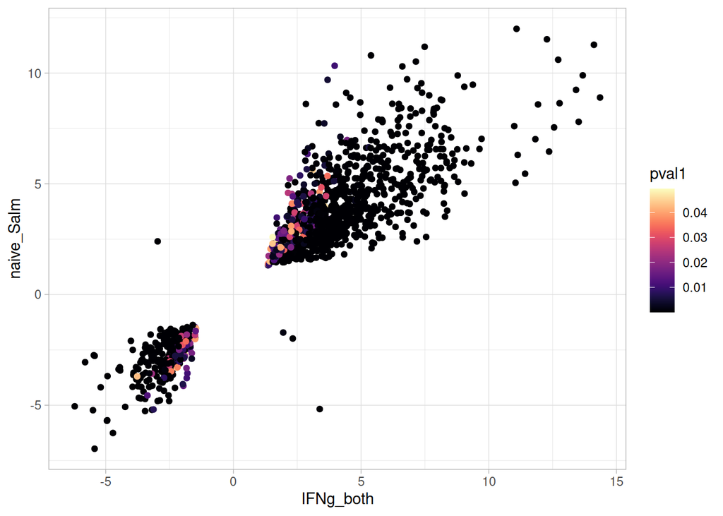

```r
deedee_scatter(data = DeeDee_obj, select1 = 2, select2 = 3, color_by = "pval1")
```

### DeeDee heatmap

The function `deedee_heatmap` creates a heatmap of the logFC values for all common genes in every input dataset. The color key is given on the right side of the plot. Additionally to the standard parameters explained in Input, heatmap takes a numeric `show_first` value (default = 25), specifying the number of genes depicted (if the total number of genes is smaller than `show_first`, all genes are shown). It also digests a logical `show_gene_names` value (default = FALSE) that determines if the gene identifiers (rownames in `deedee_prepare` results) will be displayed in the heatmap, and a logical “show_na”, defining if genes with NAs are included. Distance measure (`dist`, values: `euclidean` (default), `manhattan`, `pearson`, `spearman`) and clustering method (`clust`, values: `single`, `complete`, `average` (default), `centroid`) can be chosen.

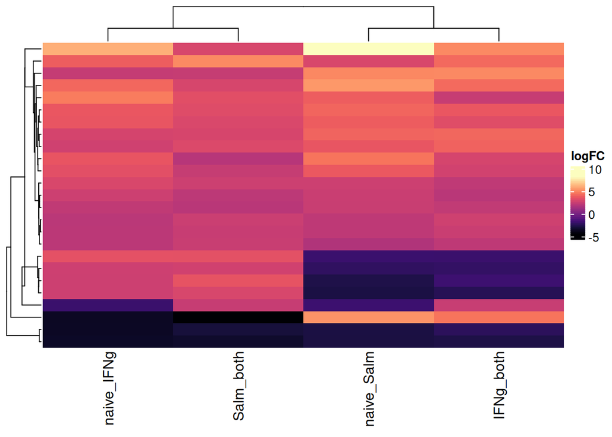

```r
deedee_heatmap(data = DeeDee_obj, pthresh = 0.05, show_first = 25, show_gene_names = FALSE, dist = "manhattan", clust = "centroid", show_na = FALSE)
```

### DeeDee Venn diagram

The function `deedee_venn` creates a Venn diagram depicting the overlaps of differentially expressed genes in the input datasets. To keep the Venn diagram easy on the eye, the `data` list may contain no more than four datasets. To compare more DEAs in a similar, set-based manner, `deedee_upSet` can be used. The parameter `mode` can be set to `up`, `down`, or `both` (default), specifying if only up-regulated, down-regulated or both DE genes shall be counted.

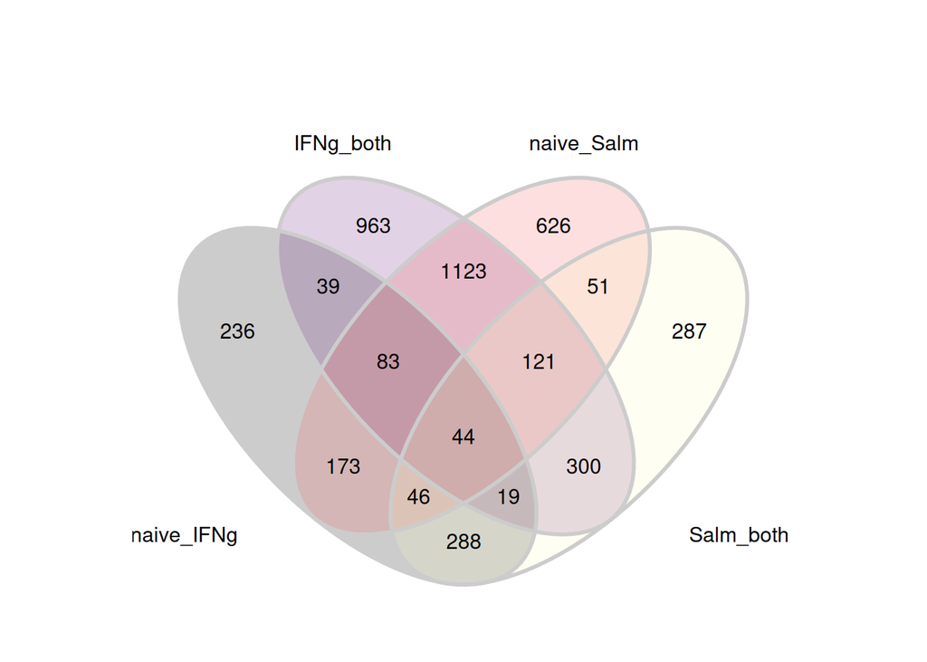

```r
deedee_venn(data = DeeDee_obj, pthresh = 0.05, mode = "both")
```

### DeeDee UpSet plot

The function `deedee_upset` creates an UpSet plot depicting the overlaps of differentially expressed genes in the input datasets. Contrary to `deedee_venn`, the UpSet plot can compare multiple (and even more than four) datasets in a visually pleasing way. The parameter `mode` can be set to `up`, `down`, `both` (default), or `both_colored`, specifying if only up-regulated, down-regulated or both DE genes shall be depicted. If `both_colored` is chosen, the result is the same UpSet plot as for `both`, but the shares of the intersections where all samples have positive/negative logFC values are colored dark-violet/light-beige. The minimum size for an intersection to be included in the plot can be defined by the parameter `min_setsize`, default is 10.

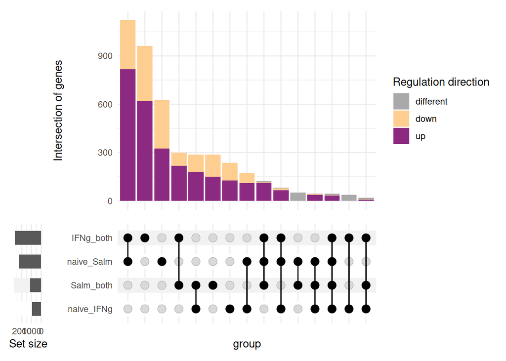

```r
deedee_upset(data = DeeDee_obj, pthresh = 0.05, mode = "both_colored", min_setsize = 15)
```

### DeeDee QQ plot

The function `deedee_qq` compares the statistical distributions of two input datasets. If the input data list contains more than two datasets (like our example `DeeDee_obj` does), the `select1` (default = 1) and `select2` (default = 2) parameters specify which ones are to be used. If the resulting curve resembles a straight line with a slope of 1, the distributions are similar (perfect straight line = identical distributions). `deedee_qq` includes a `color_by` parameter that can be set to “pval1” (default) or “pval2”. The points generating the curve will be colored according to the color key on the right of the output.

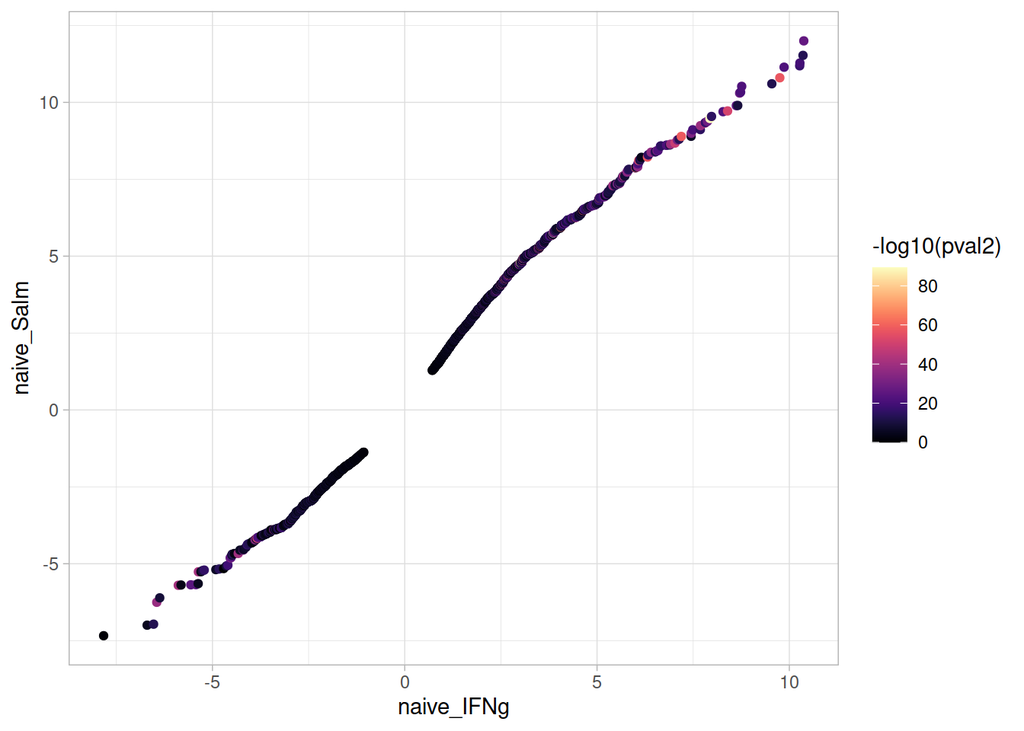

```r
deedee_qq(data = DeeDee_obj, pthresh = 0.05, select1 = 1, select2 = 3, color_by = "pval2")
```

### DeeDee CAT plot

The function `deedee_cat` creates a plot depicting Concordance At the Top curves for a reference contrast (parameter `ref` set to index of the contrast in the input dataframe). The curves indicate the share of genes that are concordant in the upper x ranks of the reference contrast and one of the other contrast, one curve per contrast is issued. The highest rank for which the concordance is calculated is given by the `maxrank` (default = 1000) parameter.

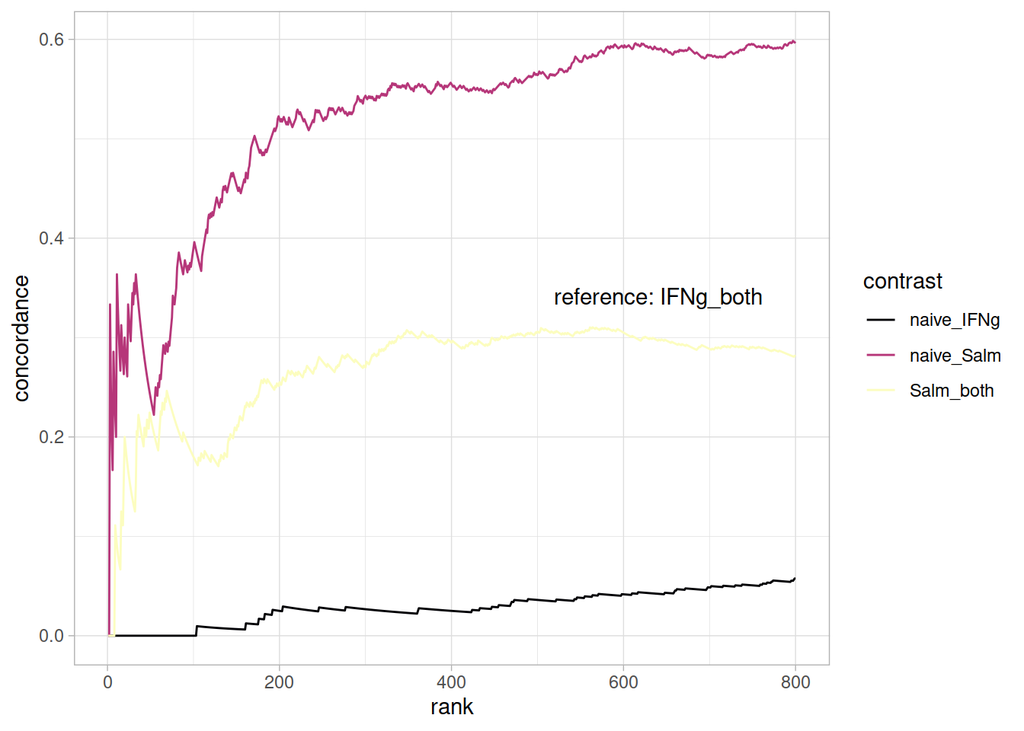

```r
deedee_cat(data = DeeDee_obj, ref = 2, pthresh = 0.05, maxrank = 800)
```